# MA 589 Final Project

Wenbin Teng, Zixin Ding, Tong Shen, & Jueru Jin

December 2, 2018

The human genome has genetic markers based on “single nucleotide polymorphisms” (SNPs) that can be used to assess the genetic risk of diseases. For instance, consider the $p = 11$ markers in file $\texttt{hla_snps.csv}$, where $\texttt{dbsnp}$ is an identifier and $\texttt{position}$ is the genomic position; these markers belong to the human leukocyte antigen (HLA) gene complex region, located in the short arm of chromosome 6. This complex encodes proteins that regulate the immune system and thus are connected to autoimmune disorders such as type I diabetes and celiac disease. File $\texttt{hla_study.csv}$ lists the results from a (hypothetical) study with $n = 100$ individuals: $\texttt{status}$ indicates disease status and the other columns count the number of allele copies of each HLA marker.

Let us assume that the disease status $Y_i$ of the $i$-th individual can be modeled using logistic regression with genotypes $\mathbf{x}_i = (x_{ij})_{j=1,...,p}, x_{ij}\in\big\{0, 1,2\big\}$:

$$Y_i|\beta_0,\tilde\beta\stackrel{iid}\sim\texttt{Bern}\big[\text{logit}^{-1}(\beta_0+\mathbf{x}_i^\top\tilde\beta)\big], i=1,...,n.$$
with $\tilde\beta=\big\{\beta_j\big\}^p_{j=1}$

The main goal here is to infer the effect of each marker in the disease status. However, as it is common in these studies, we do not expect that every marker is actually associated with the status. To account for this, we perform $variable$ $selection$ and set

$$\beta_j|\theta_j\stackrel{iid}\sim N(0,(1-\theta_j)\tau_0^2+\theta_j\tau^2), j=1,...,p$$

Since we have no prior knowledge about the intercept $\beta_0$, we can set $\mathbf{P}(\beta_0)\propto 1$. The variable inclusion indicators $\theta$ are not independent, but have dependencies coded according to a graph $G$ where two markers $u$ and $v$ are connected, $(u, v) \in G$, if and only if $|\text{pos}_u - \text{pos}_v|< 50,000$:

$$\mathbf{P}(\theta)\propto \text{exp}\Bigg\{\frac{h}{2}\sum_{u=1}^ps(\theta_u)+\frac{1}{T}\sum_{(u,v)\in G}s(\theta_u)s(\theta_v)\Bigg\}$$
where $h=-3$ and $T=10$ in the Ising prior for the variable inclusion indicators $\theta$, $s(\theta_j)=2\theta_j-1$ maps indicators $\big\{0,1\big\}$ to spins $\big\{-1,1\big\}$.

Let us now asume that $T \rightarrow \infty$ so that the prior on $\theta$ is simply

$$\mathbb{P}(\theta)\propto \exp \Bigg\{\frac{h}{2}\sum_{u=1}^p s(\theta_u) \Bigg\}$$
To obtain estimates for $\beta$, let us resort to $expectation-maximization$ (EM) where we take $\theta$ to be latent variables.

1. Start by writing out $Q(\beta;\beta^{(t)})=\mathbb{E}_{\theta|\beta=\beta^{(t)},Y}[\log\mathbb{P}(\beta,\theta,Y)]$ and showing that, for the E-step, you just need to define $\pi_j^{(t)}:=\mathbb{P}(\theta_j=1|\beta=\beta_{(t)},Y)$ as $\pi_j^{(t)}=\text{logit}^{-1}(\gamma(\beta_j^{(t)}))$ where $\gamma$ is defined as:

$$\gamma(\beta_v):=h-\frac{1}{2}\Bigg(\log\frac{\tau^2}{\tau_0^2}+\beta_v^2\Big(\frac{1}{\tau^2}-\frac{1}{\tau^2_0}\Big)\Bigg)$$

As we know from Project 5.2(a), when $T \rightarrow \infty$, we have:

$$\mathbb{P}(\theta_j|\tilde\beta,\theta_{[-j]},Y)\propto ((1-\theta_j)\tau_0^2+\theta_j\tau^2)^{-\frac{1}{2}}\exp\Bigg\{-\frac{\beta_j^2}{2((1-\theta_j)\tau_0^2+\theta_j\tau^2)}+\theta_jh\Bigg\}$$
Generate likelihood function:

$$\begin{split} L(\beta_j;\theta_j,\beta_{[-j]},Y_i) &=\prod_{i=1}^n\mathbb{P}(Y_i|\beta_j)\mathbb{P}(\beta_j|\theta_j)\mathbb{P}(\theta_j)\\
&=\prod_{i=1}^n\mu_i(\beta)^{Y_i}(1-\mu_i(\beta))^{1-Y_i}\phi(\beta_j,0,\tau^2)^{\theta_j}\phi(\beta_j,0,\tau_0^2)^{1-\theta_j}\\
l(\beta_j;\theta_j,\beta_{[-j]},Y_i)
&=\sum_{i=1}^nY_i\log(\mu_i(\beta))+(1-Y_i)\log(\mu_i(\beta))+\theta_j\log\phi(\beta_j,0,\tau^2)+(1-\theta_j)\log\phi(\beta_j,0,\tau_0^2)\\
&=\sum_{i=1}^nY_i\log\frac{\mu_i(\beta)}{1-\mu_i(\beta)}-\log\Big(1+e^{\beta_0+\mathbf{x}_i^\top \tilde\beta}\Big)+\theta_j\Bigg(-\frac{1}{2}\log\tau^2-\frac{1}{2}\log2\pi-\frac{\beta_j^2}{2\tau^2}\Bigg)+(1-\theta_j)\Bigg(-\frac{1}{2}\log\tau_0^2-\frac{1}{2}\log2\pi-\frac{\beta_j^2}{2\tau_0^2}\Bigg)
\end{split}$$

$$\pi_j^{(t)}=\mathbb{P}(\theta_j=1|\beta=\beta^{(t)},Y)=\mathbb{E}_{\theta|\beta=\beta^{(t)},Y}[I(\theta_j=1)]$$

$$\begin{split} \text{logit}\pi_j^{(t)} &= \log\frac{\pi_j^{(t)}}{1-\pi_j^{(t)}}=\log\frac{\tau_0\exp\Big\{-\frac{\beta_j^2}{2\tau^2}+h\Big\}}{\tau\exp\Big\{-\frac{\beta_j^2}{2\tau_0^2}\Big\}} \\
&=-\log\frac{\tau}{\tau_0}-\frac{\beta_j^2}{2\tau^2}+h+\frac{\beta_j^2}{2\tau_0^2}\\
&=h-\frac{1}{2}\Bigg(\log\frac{\tau^2}{\tau_0^2}+\beta_v^2\Big(\frac{1}{\tau^2}-\frac{1}{\tau^2_0}\Big)\Bigg)\\
&=\gamma(\beta_j)\\
\pi_j^{(t)}&=\text{logit}^{-1}(\gamma(\beta_j^{(t)}))\end{split}$$
Therefore,

$$\begin{split}Q(\beta;\beta^{(t)})&=\mathbb{E}_{\theta|\beta=\beta^{(t)},Y}\sum_{j=1}^pl(\beta_j;\theta_j,Y,\beta_{[-j]})\\
&=\sum_{i=1}^nY_i(\beta_0+\mathbf{x}_i^\top\tilde\beta)-\log\bigg(1+\exp\Big\{\beta_0+\mathbf{x}_i^\top\tilde\beta\Big\}\bigg)+\sum_{j=1}^p\Bigg[\pi_j^{(t)}\Bigg(-\frac{1}{2}\log\tau^2-\frac{1}{2}\log2\pi-\frac{(\beta_j^{(t)})^2}{2\tau^2}\Bigg)+(1-\pi_j^{(t)})\Bigg(-\frac{1}{2}\log\tau_0^2-\frac{1}{2}\log2\pi-\frac{(\beta_j^{(t)})^2}{2\tau_0^2}\Bigg)\Bigg]\end{split}$$

2. For the M-step, perform a $Newton-Raphson$ update, similar to what we used for logistic regression. Show that

$$\frac{\partial Q}{\partial\beta}(\beta^{(t)})=X^\top(Y-\mu(\beta^{(t)}))-\Omega(\pi^{(t)})\beta^{(t)}$$
and the negative Hessian matrix is

$$-\frac{\partial^2Q}{\partial\beta\partial\beta^\top}(\beta^{(t)})=X^\top\text{Diag}_{i=1,...,n}\big\{\mu_i(\beta^{(t)})(1-\mu_i(\beta^{(t)}))\big\}X+\Omega(\pi^{(t)})$$
where $\mu$ and $\Omega$ are defined as $\mu_i(\beta)=\text{logit}^{-1}(\beta_0+\mathbf{x}_i^\top \tilde\beta)$, $\Omega(\theta)=\text{Diag}_{j=0,1,...,p}(\omega_j(\theta_j))$, where $\omega_0=0$, $\omega_j(\theta_j)=\frac{1-\theta_j}{\tau_0^2}+\frac{\theta_j}{\tau^2}$

Taking derivative of $Q$ in $(a)$ w.r.t. $\beta_j$, we have

$$\begin{split}\frac{\partial Q(\beta_j;\beta_j^{(t)})}{\partial \beta_j}&=\sum_{i=1}^n(Y_i-\mu_i)x_{ij}+\pi_j^{(t)}\Bigg(-\frac{\beta_j^{(t)}}{\tau^2}\Bigg)+(1-\pi_j^{(t)})\Bigg(-\frac{\beta_j^{(t)}}{\tau_0^2}\Bigg)\\
&=X_j^\top(Y-\mu(\beta^{(t)}))-\omega_j(\pi_j^{(t)})\beta_j^{(t)}\\
\frac{\partial Q}{\partial\beta}(\beta^{(t)})&=X^\top(Y-\mu(\beta^{(t)}))-\Omega(\pi^{(t)})\beta^{(t)}\\
\Bigg(\frac{\partial Q}{\partial\beta}(\beta^{(t)})\Bigg)_k&=\sum_{i=1}^n(Y_i-\mu_i(\beta^{(t)}))x_{ik}-\omega_k(\pi_k^{(t)})\beta_k^{(t)}\\
-\frac{\partial^2Q}{\partial\beta\partial\beta_k}&=\sum_{i=1}^n\frac{\exp\Big\{\beta_0+\mathbf{x}_i^\top\tilde\beta\Big\}x_{ik}^2}{\Big(1+\exp\Big\{\beta_0+\mathbf{x}_i^\top\tilde\beta\Big\}\Big)^2}+\omega_k(\pi_k^{(t)})\\
&=\sum_{i=1}^n\mu_i(\beta^{t})(1-\mu_i(\beta^{t}))x_{ik}^2+\omega_k(\pi_k^{(t)})\\
-\frac{\partial^2Q}{\partial\beta\partial\beta^\top}(\beta^{(t)})&=X^\top\text{Diag}_{i=1,...,n}\big\{\mu_i(\beta^{(t)})(1-\mu_i(\beta^{(t)}))\big\}X+\Omega(\pi^{(t)})\end{split}$$

3. Apply this EM routi ne to the small HLA study and summarize your findings: which markers are deemed to be associated to the status? What are the EM estimatesfor the effect sizes for these selected markers and the intercept?

$$\begin{split}\beta^{(t+1)}&=\beta^{(t)}+\Bigg[-\frac{\partial^2Q}{\partial\beta\partial\beta^\top}(\beta^{(t)})\Bigg]^{-1}\frac{\partial Q}{\partial\beta}(\beta^{(t)})\\
&=\beta^{(t)}+\Big[X^\top\text{Diag}_{i=1,...,n}\big\{\mu_i(\beta^{(t)})(1-\mu_i(\beta^{(t)}))\big\}X+\Omega(\pi^{(t)})\Big]^{-1}\Big[X^\top(Y-\mu(\beta^{(t)}))-\Omega(\pi^{(t)})\beta^{(t)}\Big]\end{split}$$

```r
# preparation functions
inv_logit <- function (x) 1 / (1 + exp(-x))
LOGEPS <- log(.Machine$double.eps / 2)
log1pe <- function (x) {
  l <- ifelse(x > 0, x, 0)
  x <- ifelse(x > 0, -x, x)
  ifelse(x < LOGEPS, l, l + log1p(exp(x)))
}

lse2 <- local({
  LOG.EPS2 <- log(.Machine$double.eps / 2)
  function(x,y) {
    m <- pmax(x,y);d <- -abs(x-y)
    ifelse(d < LOG.EPS2,m,m+log(1+exp(d)))
  }
})
# generalize for a vector
lse <- function(l) Reduce(lse2, l)

# functions used in this model
mu_beta <- function(x,beta) {inv_logit(x %*% beta)}

# pi is the inv_logit of gamma
gamma_beta <- function(h,tau,tau0,beta) {
  h-0.5*(log(tau^2/tau0^2)+beta^2*(1/tau^2-1/tau0^2))
}

# first derivative of Q w.r.t. beta
betadl <- function(x,y,beta,h,tau,tau0) {
  pi_beta <- inv_logit(gamma_beta(h,tau,tau0,beta))
  omega_beta <- (1-pi_beta)/tau0^2 + pi_beta/tau^2
  diag_mat <- diag(as.vector(omega_beta))
  diag_mat[1,1] <- 0
  t(x) %*% (y-mu_beta(x,beta))-diag_mat %*% beta
}

# second derivative of Q w.r.t t(beta)
betadll <- function(x,y,beta,h,tau,tau0) {
  pi_beta <- inv_logit(gamma_beta(h,tau,tau0,beta))
  omega_beta <- (1-pi_beta)/tau0^2 + pi_beta/tau^2
  diag_mat <- diag(as.vector(omega_beta))
  diag_mat[1,1] <- 0
  crossprod(x, diag(as.vector(mu_beta(x,beta)*(rep(1,length(y))-mu_beta(x,beta)))) %*% x) + diag_mat
}

em_step <- function(x,y,beta_init,h=-3,tau=1,tau0=0.1,max.iteration=10000,tolerance=1e-6) {

  beta.cur <- beta_init
  time <- 0
  beta.mat <- beta.cur
  for (i in 1:max.iteration) {

    # constants using in calculating Q
    cons1 <- -0.5*log(tau^2)-0.5*log(2*pi);cons2 <- -0.5*log(tau0^2)-0.5*log(2*pi)
    cons3 <- -2*tau^2;cons4 <- -2*tau0^2

    # pi, and Q for the current time
    pi.cur <- inv_logit(gamma_beta(h,tau,tau0,beta.cur))[-1]

    Q.cur <- sum((y*(x%*%beta.cur))-log1pe(x%*%beta.cur))+sum(cons1*c(0,pi.cur)+cons2*(1-c(0,pi.cur))+(diag(as.vector(c(0,pi.cur)/cons3+(1-c(0,pi.cur))/cons4))%*%(beta.cur^2)))

    c.nxt <- chol(betadll(x,y,beta.cur,h,tau,tau0))
    betadl.nxt <- betadl(x,y,beta=beta.cur,h=h,tau=tau,tau0=tau0)
    beta.nxt <- beta.cur + backsolve(c.nxt,backsolve(c.nxt,betadl.nxt,transpose = T))

    # pi, and Q for the next time
    beta.mat <- cbind(beta.mat,beta.nxt)
    pi.nxt <- inv_logit(gamma_beta(h,tau,tau0,beta.nxt))[-1]
    Q.nxt <- sum((y*(x%*%beta.nxt))-log1pe(x%*%beta.nxt))+sum(cons1*c(0,pi.nxt)+cons2*(1-c(0,pi.nxt))+(diag(as.vector(c(0,pi.nxt)/cons3+(1-c(0,pi.nxt))/cons4))%*%(beta.nxt^2)))

    # converging conditions
    if(abs((Q.nxt-Q.cur)/Q.cur)<tolerance) break


    # make to the next time
    beta.cur <- beta.nxt
    time <- time + 1

  }
  list('beta'=beta.nxt,'pi'=pi.nxt,'time'=time,'beta.mat'=beta.mat)
}
study <- read.csv(file = "C:/Users/wbten/OneDrive/Desktop/BU/Fall 2018/MA 589/hla_study.csv")
y <- as.vector(study$status)
x <- as.matrix(unname(study[,-study$status]))
X <- cbind(rep(1,length(y)),x)
p <- ncol(X)
beta_init <- as.vector(coef(glm(y~x,family = binomial)))
```

The beta and lp outputs are:

```r
em_result <- em_step(X,y,beta_init)
drop(em_result$beta)
```

```
##  [1] -2.6850956657  0.0074950294  0.0024470894  0.0265164961  0.7303719892
##  [6]  2.6093400249 -0.0192647618 -0.0171448494  0.0006796398  0.8483657439
## [11]  1.2890998305 -0.0131264497
```

```r
em_result$pi
```

```
##  [1] 0.004967768 0.004955504 0.005128602 0.999999999 1.000000000
##  [6] 0.005045430 0.005026287 0.004954155 1.000000000 1.000000000
## [11] 0.004996264
```

Since $\theta$ has $p$ dimensions, we would like to carry out $Expectation-Conditional-Maximization$ process:

E-step: same as normal EM

$$Q(\beta;\beta^{(t)})=\mathbb{E}_{\theta|\beta=\beta^{(t)},Y}\Big[l(\beta;\theta,Y)\Big]$$
M-step: since $\beta$ has $p$ dimensions, we can perform $p$ substeps

$$\begin{split} \beta_0^{(t+1)} &= \text{argmax}_{\beta_0}Q(\beta_0,\beta_1^{(t)},\beta_2^{(t)},...,\beta_p^{(t)};\beta^{(t)})\\
\beta_1^{(t+1)} &= \text{argmax}_{\beta_1}Q(\beta_0^{(t+1)},\beta_1,\beta_2^{(t)},...,\beta_p^{(t)};\beta^{(t)})\\
\beta_2^{(t+1)} &= \text{argmax}_{\beta_2}Q(\beta_0^{(t+1)},\beta_1^{(t+1)},\beta_2,...,\beta_p^{(t)};\beta^{(t)})\\
...\\
...\\
\beta_p^{(t+1)} &= \text{argmax}_{\beta_p}Q(\beta_0^{(t+1)},\beta_1^{(t+1)},\beta_2^{(t+1)},...,\beta_p;\beta^{(t)})
\end{split}$$

To compute the argmax of each $\beta_j$, we perform $Newton-Raphson$ for $p+1$ times, the first and second derivative of Q w.r.t. $\beta_j$ is given by:

$$\frac{\partial Q}{\partial \beta_0}=\sum_{i=1}^n(Y_i-\mu_i(\beta^{(t)})),\frac{\partial^2Q}{\partial\beta_0^2}=-\sum_{i=1}^n(\mu_i(\beta^{(t)})(1-\mu_i(\beta^{(t)}))$$

$$\frac{\partial Q}{\partial \beta_j}=\sum_{i=1}^n(Y_i-\mu_i(\beta_{0:j-1}^{(t+1)},\beta_{j:p}^{(t)}))-\omega_j(\pi_j^{(t)})\beta_j^{(t)}$$
$$\frac{\partial^2Q}{\partial\beta_j^2}=-\sum_{i=1}^n\mu_i(\beta_{0:j-1}^{(t+1)},\beta_{j:p}^{(t)})(1-\mu_i(\beta_{0:j-1}^{(t+1)},\beta_{j:p}^{(t)}))-\omega_i(\pi_j^{(t)})$$

$$\beta_j^{(t+1)}=\beta_j^{(t)}-\frac{\partial Q}{\partial \beta_j}\bigg/\frac{\partial^2Q}{\partial\beta_j^2}$$

```r
em_cond <- function(x,y,beta,h=-3,tau=1,tau0=0.1,max.iteration=100,tolerance=1e-6) {
  cons1 <- -0.5*log(tau^2)-0.5*log(2*pi);cons2 <- -0.5*log(tau0^2)-0.5*log(2*pi)
  cons3 <- -2*tau^2;cons4 <- -2*tau0^2

  beta.cur <- beta
  p <-length(beta)
  time <- 0
  beta.mat <- beta.cur
  for (it in 1:max.iteration) {

    pi.cur <- inv_logit(gamma_beta(h,tau,tau0,beta.cur))[-1]
    Q.cur <- sum((y*(x%*%beta.cur))-log1pe(x%*%beta.cur))+sum(cons1*c(0,pi.cur)+cons2*(1-c(0,pi.cur))+(diag(as.vector(c(0,pi.cur)/cons3+(1-c(0,pi.cur))/cons4))%*%(beta.cur^2)))

    #print(beta.cur)
    dl0 <- sum(y-mu_beta(x,beta.cur))
    dll0 <- -sum(mu_beta(x,beta.cur)*(1-mu_beta(x,beta.cur)))
    beta.cur[1] <- beta.cur[1] - dl0/dll0
    dl <- numeric(p);dll <- numeric(p)
    dl[1] <- dl0;dll[1] <- dll0


    for (j in 2:p) {
      dl[j] <- sum((y-mu_beta(x,beta.cur))*x[,j])-(pi.cur[j-1]/tau^2)*beta.cur[j]-((1-pi.cur[j-1])/tau0^2)*beta.cur[j]
      dll[j] <- -sum(mu_beta(x,beta.cur)*(1-mu_beta(x,beta.cur))*x[,j]^2)-pi.cur[j-1]/tau^2-(1-pi.cur[j-1])/tau0^2
      beta.cur[j] <- beta.cur[j] - dl[j]/dll[j]
    }
    #print(beta.cur[1])
    beta.nxt <- beta.cur
    beta.mat <- rbind(beta.mat,beta.nxt)
    #print(beta.nxt)
    #pi.nxt <- inv_logit(gamma_beta(h,tau,tau0,beta.nxt))[-1]
    Q.nxt <- sum((y*(x%*%beta.nxt))-log1pe(x%*%beta.nxt))+sum(cons1*c(0,pi.cur)+cons2*(1-c(0,pi.cur))+(diag(as.vector(c(0,pi.cur)/cons3+(1-c(0,pi.cur))/cons4))%*%(beta.nxt^2)))

    if(abs((Q.nxt-Q.cur)/Q.cur)<tolerance) break
    #if() break
    beta.cur <- beta.nxt
    time <- time + 1
  }
  list('beta'=beta.nxt,'pi'=pi.cur,'time'=time,'beta.mat'=beta.mat)
}
y <- as.vector(study$status)
x <- as.matrix(unname(study[,-study$status]))
X <- cbind(rep(1,length(y)),x)
p <- ncol(X)
beta_init <- as.vector(coef(glm(y~x,family = binomial)))
```

The beta and lp output for ECM:

```r
em_cond_result <- em_cond(X,y,beta_init)
em_cond_result$beta
```

```
##  [1] -2.6850984358  0.0074950357  0.0024470849  0.0265164789  0.7303722888
##  [6]  2.6093413783 -0.0192647344 -0.0171448145  0.0006796549  0.8483664460
## [11]  1.2891013240 -0.0131264032
```

```r
em_cond_result$pi
```

```
##  [1] 0.004967768 0.004955504 0.005128601 0.999999999 1.000000000
##  [6] 0.005045430 0.005026287 0.004954155 1.000000000 1.000000000
## [11] 0.004996264
```

Here is a comparison between original EM and ECM. By histograms of beta, we find that there is no significant difference between this two algorithms.

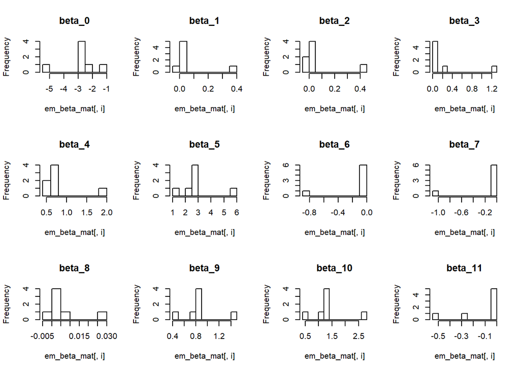

```r
em_beta_mat <- em_step(X,y,beta_init)$beta.mat
rownames(em_beta_mat) <- paste0("beta",0:11)
colnames(em_beta_mat) <- NULL
em_beta_mat <- as.data.frame(t(em_beta_mat))

par(mfrow=c(3,4))
for (i in 1:12) {
  hist(em_beta_mat[,i],main = paste0("beta_",(i-1)),breaks = 10)
}
```

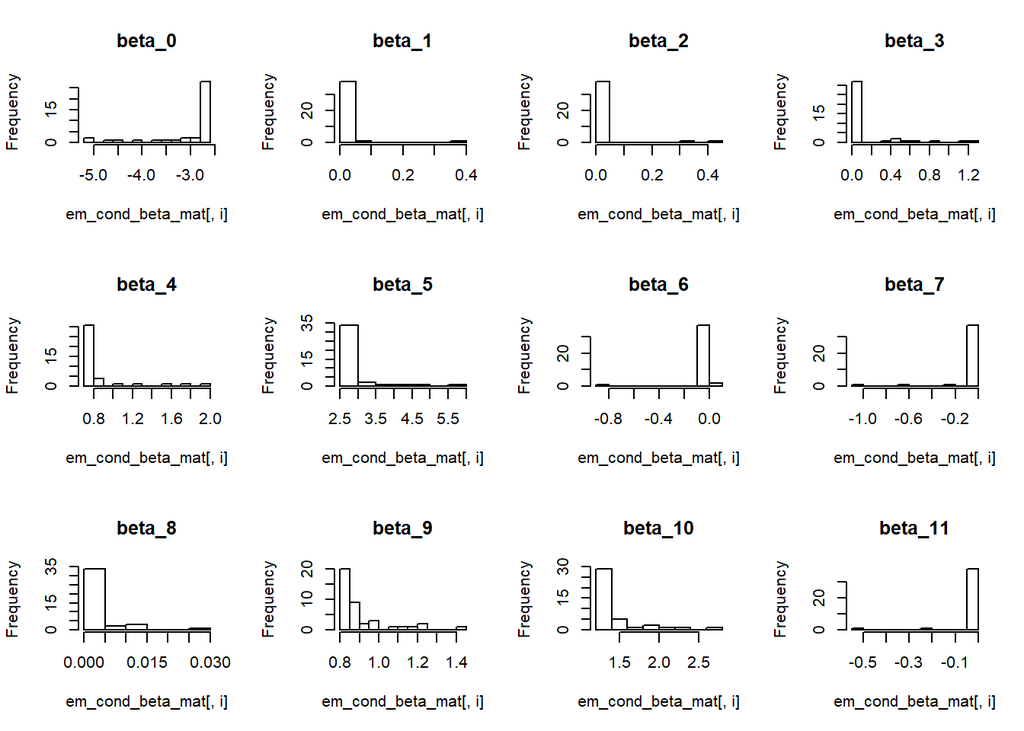

```r
em_cond_beta_mat <- em_cond(X,y,beta_init)$beta.mat
rownames(em_cond_beta_mat) <- NULL
colnames(em_cond_beta_mat) <- paste0('beta',0:11)
em_cond_beta_mat <- as.data.frame(em_cond_beta_mat)

par(mfrow=c(3,4))
for (i in 1:12) {
  hist(em_cond_beta_mat[,i],main = paste0("beta_",(i-1)),breaks = 10)
}
```

Finally,marker $\big\{0,4,5,9,10\big\}$ will be selected with $\beta=\big\{-2.685,0.73,2.609,0.848,1.289\big\}$

4. To assess the sampling distribution of the EM estimates, conduct a non-parametric Bayesian bootstrap simulation with B = 1,000 replications. Plot histograms of $\hat{\beta*}$ and report 95% “bias-corrected and accelerated” confidence intervals for each coefficient estimate. How do the EM estimates compare to the bootstrapped estimates?

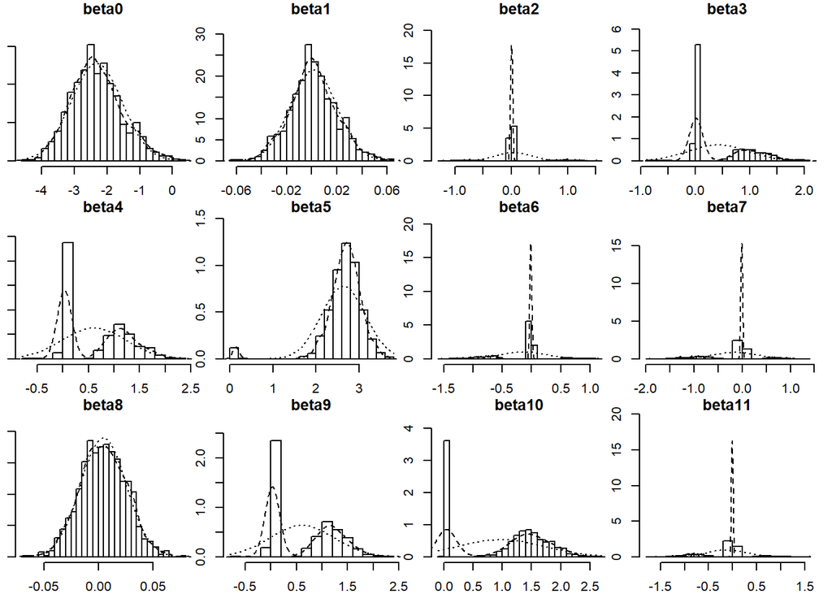

```r
bayesian_boot_sample <- function (n)
  sample.int(n, prob = diff(c(0, sort(runif(n - 1)), 1)), replace = TRUE)

bootstrap_bayesian <- function (data, beta0, g, B = 100){
  n<-nrow(data)
  p<-ncol(data)-1 #number of beta coeffficents
  beta<-matrix(0,p,B)
  for (i in 1:B){
    b.sample<-data[bayesian_boot_sample(n), ]
    x<-b.sample[,-1]
    y<-b.sample[,1]
   beta[,i]<-try(g(x,y,beta0)$beta)
  }
  return(beta)
}

data<- as.matrix(unname(cbind(study$status,rep(1,nrow(study)),study[,-study$status])))
bboot<-bootstrap_bayesian(data, beta_init, em_step, B = 1000)
rownames(bboot)<-paste0("beta", 0:11)
boot<-as.data.frame(t(bboot))


#histogram
library(psych)
multi.hist(boot,ncol=4)
```

```r
# Bayesian bootstrap (Rubin)
bayesian_boot_sample_nxt <- function (n)
  sample.int(n, prob = diff(c(0, sort(runif(n - 1)), 1)), replace = TRUE)

bootstrap_bayesian_nxt <- function (data, beta0, g, B = 100){
  n<-nrow(data)
  p<-ncol(data)-1 #number of beta coeffficents
  beta<-matrix(0,p,B)
  pis <- matrix(0,p-1,B)
  for (i in 1:B){
    b.sample<-data[bayesian_boot_sample(n), ]
    x<-b.sample[,-1]
    y<-b.sample[,1]
   beta[,i]<-try(g(x,y,beta0)$beta,TRUE)
   pis[,i] <- try(g(x,y,beta0)$pi, TRUE)
  }
  return(list(beta, pis))
}

data<- as.matrix(unname(cbind(study$status,rep(1,nrow(study)),study[,-study$status])))
bboot<-bootstrap_bayesian_nxt(data, beta_init, em_step, B = 1000)
dim(bboot[[1]])
```

```
## [1]   12 1000
```

```r
rownames(bboot[[1]])<-paste0("beta", 0:11)
rownames(bboot[[2]]) <-paste0("pi", 1:11)
bootbeta<-as.data.frame(t(bboot[[1]]))
bootpi <- as.data.frame(t(bboot[[2]]))
#bootbeta
apply(bootbeta,2,mean)
```

```
##         beta0         beta1         beta2         beta3         beta4
## -2.2921218607  0.0008683541  0.0589120285  0.4248376701  0.6142834582
##         beta5         beta6         beta7         beta8         beta9
##  2.6351726416 -0.1508513610 -0.1310507550  0.0069905301  0.5805072734
##        beta10        beta11
##  0.8994346091 -0.1158057362
```

```r
#histogram
library(tidyr)
library(ggplot2)
```

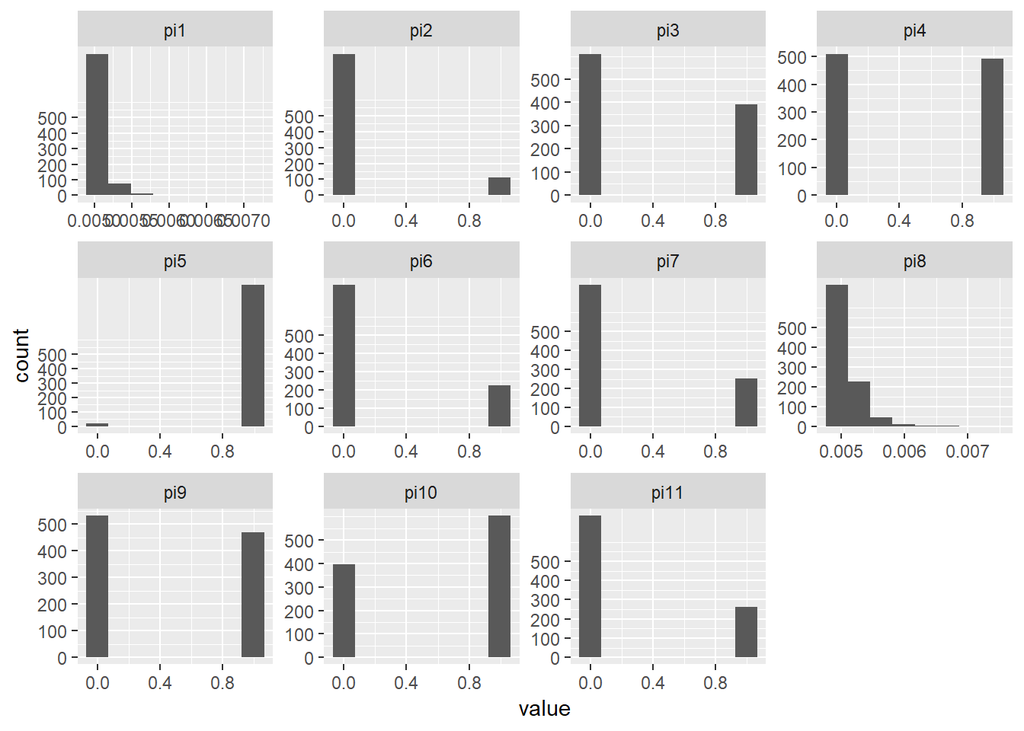

```r
bootpi %>%gather() %>% transform(key=factor(key, levels = paste0("pi",1:11))) %>% ggplot(aes(value)) + facet_wrap(~ key, scales = "free") + geom_histogram(bins = 8)+scale_y_continuous(breaks = seq(0, 500, by = 100))
```

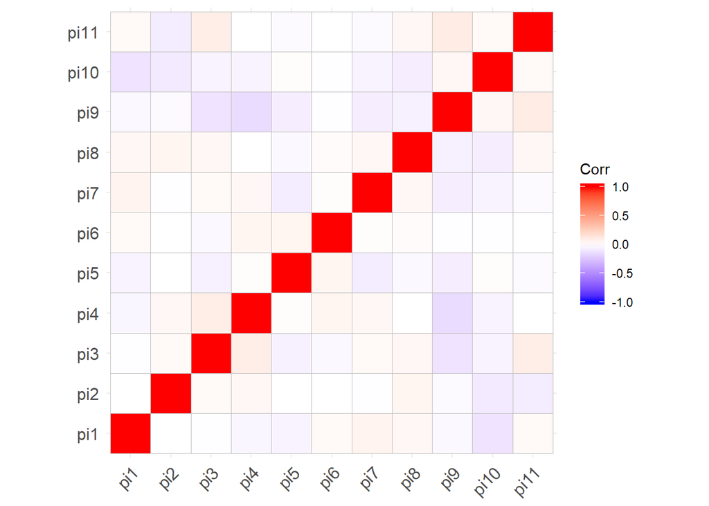

```r
library(ggcorrplot)
corr <- cor(bootpi)
ggcorrplot(corr)
```

```r
# "bias-corrected and accelerated" bootstrap CI
bcabci <- function (data, beta0, g, B = 100, alpha = .05) {
  x<-data[,-1]
  y<-data[,1]
  n <- ncol(x)
  beta.hat <- g(x,y,beta0)$beta
  # bootstrap:
  beta.boot <- bootstrap_bayesian(data, beta0, g, B = 100)

  # z0 is roughly the median bias of hat(theta)^*, in normal units:
  z0 <- numeric(n)
  a<-numeric(n)
  alpha1<-numeric(n)
  alpha2<-numeric(n)
  CI<-list()
  za <- qnorm(alpha / 2); z1a <- qnorm(1 - alpha / 2)
  for (i in 1:n) {
    z0[i] <- qnorm(mean(beta.boot[i,] < beta.hat[i]))
    # compute a
    beta.jack <- sapply(1:nrow(x), function (i) g(x[-i, ], y[-i], beta0)$beta) # jacknife
    beta.jack[i,] <- mean(beta.jack[i,]) - beta.jack[i,]
     a[i] <- sum(beta.jack[i,] ^ 3) / sum(beta.jack[i,] ^ 2) ^ 1.5 / 6 # "acceleration"
     # compute interval
    alpha1[i] <- pnorm(z0[i] + (z0[i] + za) / (1 - a[i] * (z0[i] + za)))
    alpha2[i] <- pnorm(z0[i] + (z0[i] + z1a) / (1 - a[i] * (z0[i] + z1a)))
    CI[[i]]<-quantile(beta.boot[i,],c(alpha1[i],alpha2[i]))

  }
  list(CI = CI, z0 = z0, a = a)
}


bcabci(data, beta_init, em_step,B=1000)
```

```
## $CI
## $CI[[1]]
## 0.08559709%   79.73963%
##    -4.18907    -1.53388
##
## $CI[[2]]
##   11.83763%   99.69694%
## -0.02586608  0.05016983
##
## $CI[[3]]
## 0.9288313%  94.47008%
## -0.7894534  0.9057165
##
## $CI[[4]]
## 0.08182894%   88.82575%
## -0.01791904  1.20487615
##
## $CI[[5]]
##  10.98915%  99.66472%
## 0.01556446 1.99817671
##
## $CI[[6]]
## 0.7238016%  92.57951%
##  0.1133919  3.1002773
##
## $CI[[7]]
##   1.958142%    96.8736%
## -1.03028207  0.02904854
##
## $CI[[8]]
## 0.09290628%   79.93772%
## -1.33053850  0.01457259
##
## $CI[[9]]
##   1.202377%   95.17546%
## -0.05802214  0.03242003
##
## $CI[[10]]
##   7.521438%   99.55957%
## 0.008179956 1.822995868
##
## $CI[[11]]
##  12.19285%  99.96473%
## 0.03640404 2.67612269
##
## $CI[[12]]
## 1.322994% 95.77155%
## -1.224623  0.829673
##
##
## $z0
##  [1] -0.55338472  0.38532047 -0.15096922 -0.22754498  0.35845879
##  [6] -0.27931903 -0.02506891 -0.55338472 -0.15096922  0.17637416
## [11]  0.22754498 -0.07526986
##
## $a
##  [1] -0.010690415  0.002502486 -0.019787454 -0.114881823  0.006277696
##  [6]  0.015128266 -0.012949027 -0.007042041  0.001245087  0.058760898
## [11]  0.140675753 -0.024953313
```

5. The i-th Pearson residual is defined as
   $$\hat{e_i}=\frac{Y_i-\mu(\hat{\beta})}{\sqrt{\mu(\hat{\beta})-(1-\mu(\hat{\beta}))}}$$

where $\hat{\beta}$ are the EM-estimated coefficients. Let us estimate the distribution of the Pearson residuals using a normal kernel with bandwidth $h$,
$$\hat{f_h(e)}=\frac{1}{h}\sum_{i=1}^{n}\frac{1}{n}\phi(\frac{e-\hat{e_i}}{h})$$

where $\phi$ is the standard normal density. Start by plotting the cross-validation estimate of the integrated square error $J$ (modulo a constant) to decide the best bandwidth:

$$\hat{J}(h)=\int\hat{f_h^2}(z)dz-\frac{2}{h}\sum_{i=1}^{n}\hat{f_{h,-i}}(\hat{e_i})$$
where $\hat{f_{h,-i}}$ is the density estimate based on the data without the $i$-th residual. Report the bandwidth $h*$ that minimizes $\hat{J}(h)$.

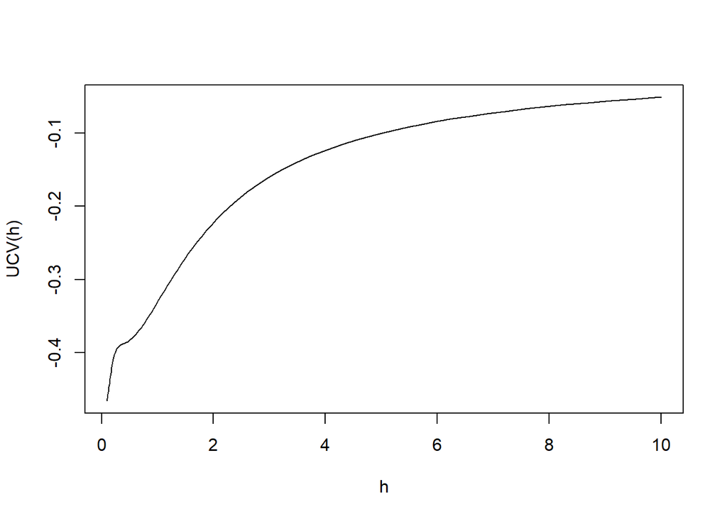

```r
beta<-em_step(X, y,beta_init)$beta
mu<-mu_beta(X,beta)
x <- (y - mu)/ sqrt( mu * (1 - mu))


kgaussian <- dnorm

kdensity <- function (x, K, h)
  function (t) mean(K((t - x) / h)) / h # f^_h(t)


plot_density <- function (x, h, K = dnorm, ns = 100) { #use Gaussian
  n <- length(x)
  f <- kdensity(x, K, h)
  t <- seq(min(x) - sd(x), max(x) + sd(x), length = ns)
  y <- sapply(t, f)
  plot(t, y, ylim = c(0, max(y)), type = 'l',
       main = paste0('h = ', sprintf('%.2f', h)),
       lwd = 2, xlab = 'x', ylab = expression(hat(f)[h]))
  for (xi in x)
    lines(t, K((t - xi) / h) / (n * h), lty = 2)
  rug(x)
  invisible(f)
}

# unbiased CV: `h` is bandwidth, `x` is data, `K` is kernel,
# `w` is kernel width in bandwidth units (e.g., w = 3 for Gaussian kernel),
# and `n` is integral grid resolution (#subdivisions)
ucv <- function (h, x, K = dnorm, w = 3, n = 100) {
  fhat2 <- function (t) (mean(K((t - x) / h)) / h) ^ 2
  fhat2vec <- function (xs) sapply(xs, fhat2)
  from <- min(x) - w * h; to <- max(x) + w * h
  J <- integrate(fhat2vec, from, to, subdivisions = n)$value # R(fhat)
  J - 2 * mean(sapply(seq_along(x),
                      function (i) mean(K((x[i] - x[-i]) / h)) / h))
}


# try plot.density



hs <- 10 ^ seq(-1, 1, length = 100)
uh <- sapply(hs, ucv, x)
h.star <- hs[which.min(uh)]
plot(hs, uh, type = 'l', xlab='h', ylab='UCV(h)')
```

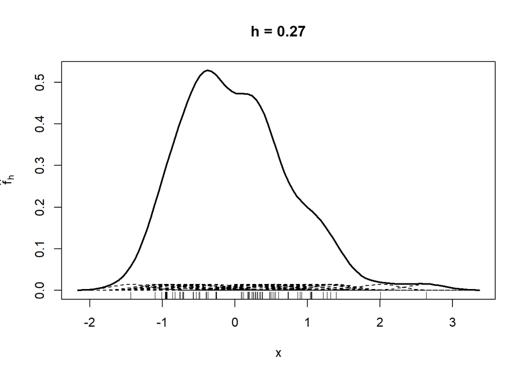

```r
plot_density(x, bw.nrd(x)) # Silverman's rule of thumb; included
```

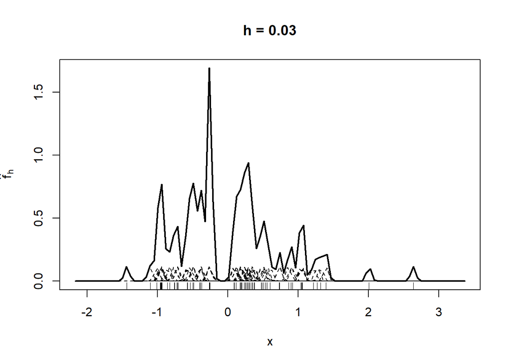

```r
plot_density(x, bw.ucv(x)) # R' UCV; included
```

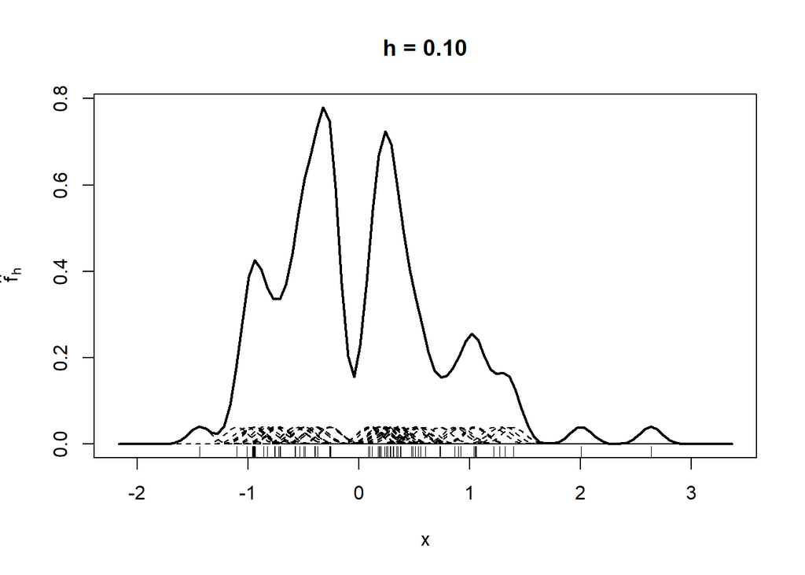

```r
plot_density(x, h.star)
```

```r
paste("The bandwidth h* that minimizes J(h) is",h.star)
```

```
## [1] "The bandwidth h* that minimizes J(h) is 0.1"
```